# Optimal Treatment Analysis

## Outcome Variable

**Outcome Variable:** whz

## Predictor Variables

**Intervention Variable:** perdiar24

**Adjustment Set:**

- arm
- sex
- meducyrs
- feducyrs
- hhwealth_quart
- hfoodsec
- vagbrth
- hdlvry
- W_birthwt
- W_birthlen
- single
- W_nrooms
- month
- brthmon
- impfloor
- impsan
- safeh20
- delta_meducyrs
- delta_feducyrs
- delta_hhwealth_quart
- delta_hfoodsec
- delta_vagbrth
- delta_hdlvry
- delta_W_birthwt
- delta_W_birthlen
- delta_single
- delta_W_nrooms
- delta_month
- delta_brthmon
- delta_impfloor
- delta_impsan
- delta_safeh20

## Stratifying Variables

The analysis was stratified on these variable(s):

- agecat
- studyid
- country

## Data Summary

| agecat | studyid | country | perdiar24 | n_cell | n |
| --- | --- | --- | --- | --- | --- |
| Birth | ki0047075b-MAL-ED | BANGLADESH | 0% | 14 | 215 |
| Birth | ki0047075b-MAL-ED | BANGLADESH | (0%, 5%] | 127 | 215 |
| Birth | ki0047075b-MAL-ED | BANGLADESH | >5% | 74 | 215 |
| Birth | ki0047075b-MAL-ED | BRAZIL | 0% | 34 | 62 |
| Birth | ki0047075b-MAL-ED | BRAZIL | (0%, 5%] | 26 | 62 |
| Birth | ki0047075b-MAL-ED | BRAZIL | >5% | 2 | 62 |
| Birth | ki0047075b-MAL-ED | INDIA | 0% | 5 | 45 |
| Birth | ki0047075b-MAL-ED | INDIA | (0%, 5%] | 31 | 45 |
| Birth | ki0047075b-MAL-ED | INDIA | >5% | 9 | 45 |
| Birth | ki0047075b-MAL-ED | NEPAL | 0% | 2 | 26 |
| Birth | ki0047075b-MAL-ED | NEPAL | (0%, 5%] | 19 | 26 |
| Birth | ki0047075b-MAL-ED | NEPAL | >5% | 5 | 26 |
| Birth | ki0047075b-MAL-ED | PERU | 0% | 21 | 228 |
| Birth | ki0047075b-MAL-ED | PERU | (0%, 5%] | 87 | 228 |
| Birth | ki0047075b-MAL-ED | PERU | >5% | 120 | 228 |
| Birth | ki0047075b-MAL-ED | SOUTH AFRICA | 0% | 42 | 112 |
| Birth | ki0047075b-MAL-ED | SOUTH AFRICA | (0%, 5%] | 69 | 112 |
| Birth | ki0047075b-MAL-ED | SOUTH AFRICA | >5% | 1 | 112 |
| Birth | ki0047075b-MAL-ED | TANZANIA, UNITED REPUBLIC OF | 0% | 7 | 115 |
| Birth | ki0047075b-MAL-ED | TANZANIA, UNITED REPUBLIC OF | (0%, 5%] | 77 | 115 |
| Birth | ki0047075b-MAL-ED | TANZANIA, UNITED REPUBLIC OF | >5% | 31 | 115 |
| Birth | ki1000109-EE | PAKISTAN | 0% | 115 | 177 |
| Birth | ki1000109-EE | PAKISTAN | (0%, 5%] | 62 | 177 |
| Birth | ki1000109-EE | PAKISTAN | >5% | 0 | 177 |
| Birth | ki1017093-NIH-Birth | BANGLADESH | 0% | 46 | 572 |
| Birth | ki1017093-NIH-Birth | BANGLADESH | (0%, 5%] | 327 | 572 |
| Birth | ki1017093-NIH-Birth | BANGLADESH | >5% | 199 | 572 |
| Birth | ki1017093b-PROVIDE | BANGLADESH | 0% | 55 | 532 |
| Birth | ki1017093b-PROVIDE | BANGLADESH | (0%, 5%] | 322 | 532 |
| Birth | ki1017093b-PROVIDE | BANGLADESH | >5% | 155 | 532 |

[output cut: 102 more lines]

The following strata were considered:

- agecat: 24 months, studyid: ki0047075b-MAL-ED, country: BANGLADESH
- agecat: 24 months, studyid: ki0047075b-MAL-ED, country: BRAZIL
- agecat: 24 months, studyid: ki0047075b-MAL-ED, country: INDIA
- agecat: 24 months, studyid: ki0047075b-MAL-ED, country: NEPAL
- agecat: 24 months, studyid: ki0047075b-MAL-ED, country: PERU
- agecat: 24 months, studyid: ki0047075b-MAL-ED, country: SOUTH AFRICA
- agecat: 24 months, studyid: ki0047075b-MAL-ED, country: TANZANIA, UNITED REPUBLIC OF
- agecat: 24 months, studyid: ki1000109-EE, country: PAKISTAN
- agecat: 24 months, studyid: ki1017093-NIH-Birth, country: BANGLADESH
- agecat: 24 months, studyid: ki1017093b-PROVIDE, country: BANGLADESH
- agecat: 24 months, studyid: ki1017093c-NIH-Crypto, country: BANGLADESH
- agecat: 24 months, studyid: ki1114097-CMIN, country: BANGLADESH
- agecat: 24 months, studyid: ki1114097-CONTENT, country: PERU
- agecat: 24 months, studyid: kiGH5241-JiVitA-4, country: BANGLADESH
- agecat: 6 months, studyid: ki0047075b-MAL-ED, country: BANGLADESH
- agecat: 6 months, studyid: ki0047075b-MAL-ED, country: BRAZIL
- agecat: 6 months, studyid: ki0047075b-MAL-ED, country: INDIA
- agecat: 6 months, studyid: ki0047075b-MAL-ED, country: NEPAL
- agecat: 6 months, studyid: ki0047075b-MAL-ED, country: PERU
- agecat: 6 months, studyid: ki0047075b-MAL-ED, country: SOUTH AFRICA
- agecat: 6 months, studyid: ki0047075b-MAL-ED, country: TANZANIA, UNITED REPUBLIC OF
- agecat: 6 months, studyid: ki1000109-EE, country: PAKISTAN
- agecat: 6 months, studyid: ki1000304b-SAS-FoodSuppl, country: INDIA
- agecat: 6 months, studyid: ki1017093-NIH-Birth, country: BANGLADESH
- agecat: 6 months, studyid: ki1017093b-PROVIDE, country: BANGLADESH
- agecat: 6 months, studyid: ki1017093c-NIH-Crypto, country: BANGLADESH
- agecat: 6 months, studyid: ki1112895-Guatemala BSC, country: GUATEMALA
- agecat: 6 months, studyid: ki1114097-CMIN, country: BANGLADESH
- agecat: 6 months, studyid: ki1114097-CONTENT, country: PERU
- agecat: 6 months, studyid: kiGH5241-JiVitA-4, country: BANGLADESH
- agecat: Birth, studyid: ki0047075b-MAL-ED, country: BANGLADESH
- agecat: Birth, studyid: ki0047075b-MAL-ED, country: BRAZIL
- agecat: Birth, studyid: ki0047075b-MAL-ED, country: INDIA
- agecat: Birth, studyid: ki0047075b-MAL-ED, country: NEPAL
- agecat: Birth, studyid: ki0047075b-MAL-ED, country: PERU
- agecat: Birth, studyid: ki0047075b-MAL-ED, country: SOUTH AFRICA
- agecat: Birth, studyid: ki0047075b-MAL-ED, country: TANZANIA, UNITED REPUBLIC OF
- agecat: Birth, studyid: ki1000109-EE, country: PAKISTAN
- agecat: Birth, studyid: ki1017093-NIH-Birth, country: BANGLADESH
- agecat: Birth, studyid: ki1017093b-PROVIDE, country: BANGLADESH
- agecat: Birth, studyid: ki1017093c-NIH-Crypto, country: BANGLADESH
- agecat: Birth, studyid: ki1114097-CMIN, country: BANGLADESH
- agecat: Birth, studyid: ki1114097-CONTENT, country: PERU
- agecat: Birth, studyid: kiGH5241-JiVitA-4, country: BANGLADESH

### Dropped Strata

Some strata were dropped due to rare outcomes:

- agecat: Birth, studyid: ki0047075b-MAL-ED, country: BRAZIL
- agecat: Birth, studyid: ki0047075b-MAL-ED, country: NEPAL
- agecat: Birth, studyid: ki0047075b-MAL-ED, country: SOUTH AFRICA
- agecat: Birth, studyid: ki1000109-EE, country: PAKISTAN
- agecat: Birth, studyid: ki1114097-CMIN, country: BANGLADESH
- agecat: Birth, studyid: ki1114097-CONTENT, country: PERU
- agecat: 6 months, studyid: ki0047075b-MAL-ED, country: BRAZIL
- agecat: 6 months, studyid: ki0047075b-MAL-ED, country: INDIA
- agecat: 6 months, studyid: ki0047075b-MAL-ED, country: SOUTH AFRICA
- agecat: 6 months, studyid: ki1000109-EE, country: PAKISTAN
- agecat: 6 months, studyid: ki1114097-CMIN, country: BANGLADESH
- agecat: 24 months, studyid: ki0047075b-MAL-ED, country: BRAZIL
- agecat: 24 months, studyid: ki0047075b-MAL-ED, country: INDIA
- agecat: 24 months, studyid: ki0047075b-MAL-ED, country: PERU
- agecat: 24 months, studyid: ki0047075b-MAL-ED, country: SOUTH AFRICA
- agecat: 24 months, studyid: ki1000109-EE, country: PAKISTAN
- agecat: 24 months, studyid: ki1114097-CMIN, country: BANGLADESH
- agecat: 24 months, studyid: ki1114097-CONTENT, country: PERU

## Methods Detail

We’re interested in the causal parameters $E[Y_a]$ for all values of $a \in \mathcal{A}$. These parameters represent the mean outcome if, possibly contrary to fact, we intervened to set all units to have $A=a$. Under the randomization and positivity assumptions, these are identified by the statistical parameters $\psi_a=E_W[E_{Y|A,W}(Y|A=a,W)]$. In addition, we’re interested in the mean of $Y$, $E[Y]$ under no intervention (the observed mean). We will estimate these parameters by using SuperLearner to fit the relevant likelihood factors – $E_{Y|A,W}(Y|A=a,W)$ and $p(A=a|W)$, and then updating our likelihood fit using a joint TMLE.

For unadjusted analyses ($W=\{\}$), initial likelihoods were estimated using Lrnr_glm to estimate the simple $E(Y|A)$ and Lrnr_mean to estimate $p(A)$. For adjusted analyses, a small library containing Lrnr_glmnet, Lrnr_xgboost, and Lrnr_mean was used.

# Results Detail

## Results Plots

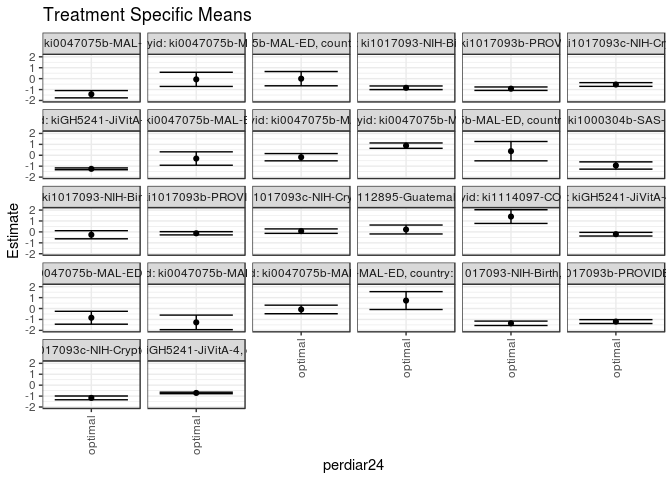

## Results Table

### Parameter: TSM

| agecat | studyid | country | intervention_level | baseline_level | estimate | ci_lower | ci_upper |
| --- | --- | --- | --- | --- | --- | --- | --- |
| Birth | ki0047075b-MAL-ED | BANGLADESH | optimal | observed | -0.8436856 | -1.4356359 | -0.2517354 |
| Birth | ki0047075b-MAL-ED | INDIA | optimal | observed | -1.2676736 | -1.9359435 | -0.5994037 |
| Birth | ki0047075b-MAL-ED | PERU | optimal | observed | -0.0842028 | -0.4754187 | 0.3070132 |
| Birth | ki0047075b-MAL-ED | TANZANIA, UNITED REPUBLIC OF | optimal | observed | 0.7294673 | -0.0881494 | 1.5470840 |
| Birth | ki1017093-NIH-Birth | BANGLADESH | optimal | observed | -1.3522873 | -1.5545824 | -1.1499921 |
| Birth | ki1017093b-PROVIDE | BANGLADESH | optimal | observed | -1.1962107 | -1.3744127 | -1.0180088 |
| Birth | ki1017093c-NIH-Crypto | BANGLADESH | optimal | observed | -1.1656061 | -1.3389054 | -0.9923069 |
| Birth | kiGH5241-JiVitA-4 | BANGLADESH | optimal | observed | -0.7113654 | -0.7786029 | -0.6441280 |
| 6 months | ki0047075b-MAL-ED | BANGLADESH | optimal | observed | -0.2993611 | -0.9131449 | 0.3144228 |
| 6 months | ki0047075b-MAL-ED | NEPAL | optimal | observed | -0.1760200 | -0.5100768 | 0.1580367 |
| 6 months | ki0047075b-MAL-ED | PERU | optimal | observed | 0.8821836 | 0.6361872 | 1.1281800 |
| 6 months | ki0047075b-MAL-ED | TANZANIA, UNITED REPUBLIC OF | optimal | observed | 0.3750653 | -0.5108761 | 1.2610068 |
| 6 months | ki1000304b-SAS-FoodSuppl | INDIA | optimal | observed | -0.9366225 | -1.2690068 | -0.6042382 |
| 6 months | ki1017093-NIH-Birth | BANGLADESH | optimal | observed | -0.2616490 | -0.6320817 | 0.1087838 |
| 6 months | ki1017093b-PROVIDE | BANGLADESH | optimal | observed | -0.1272416 | -0.2753262 | 0.0208430 |
| 6 months | ki1017093c-NIH-Crypto | BANGLADESH | optimal | observed | 0.0709841 | -0.1329736 | 0.2749418 |
| 6 months | ki1112895-Guatemala BSC | GUATEMALA | optimal | observed | 0.2195407 | -0.1903914 | 0.6294728 |
| 6 months | ki1114097-CONTENT | PERU | optimal | observed | 1.4042956 | 0.7775246 | 2.0310665 |
| 6 months | kiGH5241-JiVitA-4 | BANGLADESH | optimal | observed | -0.2111104 | -0.3802986 | -0.0419223 |
| 24 months | ki0047075b-MAL-ED | BANGLADESH | optimal | observed | -1.4273027 | -1.7617012 | -1.0929041 |
| 24 months | ki0047075b-MAL-ED | NEPAL | optimal | observed | -0.0656168 | -0.7143498 | 0.5831163 |
| 24 months | ki0047075b-MAL-ED | TANZANIA, UNITED REPUBLIC OF | optimal | observed | -0.0029052 | -0.6569219 | 0.6511115 |
| 24 months | ki1017093-NIH-Birth | BANGLADESH | optimal | observed | -0.8376033 | -1.0035449 | -0.6716616 |
| 24 months | ki1017093b-PROVIDE | BANGLADESH | optimal | observed | -0.9191272 | -1.0770621 | -0.7611923 |
| 24 months | ki1017093c-NIH-Crypto | BANGLADESH | optimal | observed | -0.5383796 | -0.7093943 | -0.3673649 |
| 24 months | kiGH5241-JiVitA-4 | BANGLADESH | optimal | observed | -1.2428785 | -1.3256143 | -1.1601428 |

### Parameter: E(Y)

| agecat | studyid | country | intervention_level | baseline_level | estimate | ci_lower | ci_upper |
| --- | --- | --- | --- | --- | --- | --- | --- |
| Birth | ki0047075b-MAL-ED | BANGLADESH | observed | observed | -0.9412093 | -1.0864308 | -0.7959878 |
| Birth | ki0047075b-MAL-ED | INDIA | observed | observed | -0.9324444 | -1.2067907 | -0.6580982 |
| Birth | ki0047075b-MAL-ED | PERU | observed | observed | -0.0520175 | -0.1725298 | 0.0684947 |
| Birth | ki0047075b-MAL-ED | TANZANIA, UNITED REPUBLIC OF | observed | observed | 0.7624348 | 0.5710709 | 0.9537986 |
| Birth | ki1017093-NIH-Birth | BANGLADESH | observed | observed | -1.3525437 | -1.4473932 | -1.2576942 |
| Birth | ki1017093b-PROVIDE | BANGLADESH | observed | observed | -1.2984586 | -1.3752758 | -1.2216415 |
| Birth | ki1017093c-NIH-Crypto | BANGLADESH | observed | observed | -1.2441513 | -1.3281130 | -1.1601897 |
| Birth | kiGH5241-JiVitA-4 | BANGLADESH | observed | observed | -0.6886269 | -0.7410452 | -0.6362086 |
| 6 months | ki0047075b-MAL-ED | BANGLADESH | observed | observed | -0.1383956 | -0.2672708 | -0.0095204 |
| 6 months | ki0047075b-MAL-ED | NEPAL | observed | observed | 0.1110452 | -0.0202712 | 0.2423616 |
| 6 months | ki0047075b-MAL-ED | PERU | observed | observed | 1.0568987 | 0.9352990 | 1.1784983 |
| 6 months | ki0047075b-MAL-ED | TANZANIA, UNITED REPUBLIC OF | observed | observed | 0.5362213 | 0.4049390 | 0.6675036 |
| 6 months | ki1000304b-SAS-FoodSuppl | INDIA | observed | observed | -1.0121579 | -1.1280429 | -0.8962729 |
| 6 months | ki1017093-NIH-Birth | BANGLADESH | observed | observed | -0.4474038 | -0.5378167 | -0.3569909 |
| 6 months | ki1017093b-PROVIDE | BANGLADESH | observed | observed | -0.1990907 | -0.2817968 | -0.1163845 |
| 6 months | ki1017093c-NIH-Crypto | BANGLADESH | observed | observed | 0.0297622 | -0.0491685 | 0.1086930 |
| 6 months | ki1112895-Guatemala BSC | GUATEMALA | observed | observed | -0.0840134 | -0.1945572 | 0.0265305 |
| 6 months | ki1114097-CONTENT | PERU | observed | observed | 1.0684318 | 0.9515274 | 1.1853362 |
| 6 months | kiGH5241-JiVitA-4 | BANGLADESH | observed | observed | -0.3898055 | -0.4270507 | -0.3525603 |
| 24 months | ki0047075b-MAL-ED | BANGLADESH | observed | observed | -0.8201887 | -0.9423967 | -0.6979806 |
| 24 months | ki0047075b-MAL-ED | NEPAL | observed | observed | -0.3764474 | -0.4898516 | -0.2630431 |
| 24 months | ki0047075b-MAL-ED | TANZANIA, UNITED REPUBLIC OF | observed | observed | 0.0539486 | -0.0712465 | 0.1791437 |
| 24 months | ki1017093-NIH-Birth | BANGLADESH | observed | observed | -0.9115790 | -1.0095022 | -0.8136559 |
| 24 months | ki1017093b-PROVIDE | BANGLADESH | observed | observed | -0.8928670 | -0.9755153 | -0.8102187 |
| 24 months | ki1017093c-NIH-Crypto | BANGLADESH | observed | observed | -0.6103502 | -0.7050157 | -0.5156847 |
| 24 months | kiGH5241-JiVitA-4 | BANGLADESH | observed | observed | -1.2231088 | -1.2549632 | -1.1912543 |

### Parameter: PAR

| agecat | studyid | country | intervention_level | baseline_level | estimate | ci_lower | ci_upper |
| --- | --- | --- | --- | --- | --- | --- | --- |
| Birth | ki0047075b-MAL-ED | BANGLADESH | optimal | observed | -0.0975237 | -0.6628124 | 0.4677651 |
| Birth | ki0047075b-MAL-ED | INDIA | optimal | observed | 0.3352291 | -0.2656803 | 0.9361385 |
| Birth | ki0047075b-MAL-ED | PERU | optimal | observed | 0.0321852 | -0.3469547 | 0.4113251 |
| Birth | ki0047075b-MAL-ED | TANZANIA, UNITED REPUBLIC OF | optimal | observed | 0.0329675 | -0.7583111 | 0.8242461 |
| Birth | ki1017093-NIH-Birth | BANGLADESH | optimal | observed | -0.0002564 | -0.1951689 | 0.1946561 |
| Birth | ki1017093b-PROVIDE | BANGLADESH | optimal | observed | -0.1022479 | -0.2691514 | 0.0646555 |
| Birth | ki1017093c-NIH-Crypto | BANGLADESH | optimal | observed | -0.0785452 | -0.2296335 | 0.0725431 |
| Birth | kiGH5241-JiVitA-4 | BANGLADESH | optimal | observed | 0.0227386 | -0.0207402 | 0.0662173 |
| 6 months | ki0047075b-MAL-ED | BANGLADESH | optimal | observed | 0.1609655 | -0.4495748 | 0.7715058 |
| 6 months | ki0047075b-MAL-ED | NEPAL | optimal | observed | 0.2870652 | -0.0174616 | 0.5915921 |
| 6 months | ki0047075b-MAL-ED | PERU | optimal | observed | 0.1747151 | -0.0281278 | 0.3775580 |
| 6 months | ki0047075b-MAL-ED | TANZANIA, UNITED REPUBLIC OF | optimal | observed | 0.1611560 | -0.6961893 | 1.0185013 |
| 6 months | ki1000304b-SAS-FoodSuppl | INDIA | optimal | observed | -0.0755354 | -0.3885848 | 0.2375140 |
| 6 months | ki1017093-NIH-Birth | BANGLADESH | optimal | observed | -0.1857548 | -0.5574397 | 0.1859301 |
| 6 months | ki1017093b-PROVIDE | BANGLADESH | optimal | observed | -0.0718491 | -0.1974187 | 0.0537205 |
| 6 months | ki1017093c-NIH-Crypto | BANGLADESH | optimal | observed | -0.0412219 | -0.2306970 | 0.1482533 |
| 6 months | ki1112895-Guatemala BSC | GUATEMALA | optimal | observed | -0.3035541 | -0.6924928 | 0.0853847 |
| 6 months | ki1114097-CONTENT | PERU | optimal | observed | -0.3358638 | -0.9587481 | 0.2870205 |
| 6 months | kiGH5241-JiVitA-4 | BANGLADESH | optimal | observed | -0.1786951 | -0.3416051 | -0.0157850 |
| 24 months | ki0047075b-MAL-ED | BANGLADESH | optimal | observed | 0.6071140 | 0.2680967 | 0.9461313 |
| 24 months | ki0047075b-MAL-ED | NEPAL | optimal | observed | -0.3108306 | -0.9382315 | 0.3165704 |
| 24 months | ki0047075b-MAL-ED | TANZANIA, UNITED REPUBLIC OF | optimal | observed | 0.0568538 | -0.5914183 | 0.7051259 |
| 24 months | ki1017093-NIH-Birth | BANGLADESH | optimal | observed | -0.0739758 | -0.2110067 | 0.0630552 |
| 24 months | ki1017093b-PROVIDE | BANGLADESH | optimal | observed | 0.0262602 | -0.1098523 | 0.1623727 |
| 24 months | ki1017093c-NIH-Crypto | BANGLADESH | optimal | observed | -0.0719706 | -0.2268612 | 0.0829200 |
| 24 months | kiGH5241-JiVitA-4 | BANGLADESH | optimal | observed | 0.0197698 | -0.0571582 | 0.0966978 |